# HW6: CI for Cartwheel agent evaluations

Every number is computed from the committed files and the local Harbor jobs in `.harbor/jobs`. Rendering calls no model:

```bash
uv run --with jupyter quarto render analysis/report/hw6.qmd
```

```python
import json
import re
import sys
from pathlib import Path

# Run from anywhere inside the repository.
ROOT = next(p for p in [Path.cwd(), *Path.cwd().parents] if (p / "pyproject.toml").exists())
sys.path.insert(0, str(ROOT))

import matplotlib.pyplot as plt
from IPython.display import Markdown, display

from tests.eval.passk import (
    case_passes, pass_at_k, pass_at_k_bootstrap, pass_at_k_clopper_pearson, pass_hat_k, pass_hat_k_bootstrap,
)

JOBS = ROOT / ".harbor/jobs"
CASES = {c["id"]: c for c in map(json.loads, filter(str.strip, (ROOT / "eval_cases/cases.jsonl").read_text().splitlines()))}
MODES = {m["name"]: m for m in json.loads((ROOT / "analysis/state/patterns.json").read_text())["modes"]}
CI = json.loads((ROOT / "ci-runs.json").read_text())

# Cases shown in the video.
REGRESSION_EXAMPLE = "e-011"  # also the case broken on purpose in Part D
CAPABILITY_EXAMPLE = "e-002"
PASSK_EXAMPLE = "e-004"  # Part C worked example; has a 15-run analysis
# Part E analyses: case -> 15-run Harbor job. e-004 uses code checks only;
# e-008 and e-009 are decided by the frozen narrates_or_overexplains-v6 judge.
TRIAL_COUNT_JOBS = {
    "e-004": "hw6-capability-15",
    "e-008": "hw6-capability-15-e-008",
    "e-009": "hw6-capability-15-e-009",
}
# e-009 and e-012 each had a VerifierTimeoutError in hw6-baseline, so their
# five baseline runs come from the rerun job.
BASELINE_JOB = {cid: "hw6-baseline-rerun" if cid in {"e-009", "e-012"} else "hw6-baseline" for cid in CASES}

INK, INK2, GRID, SURF = "#0b0b0b", "#52514e", "#e4e3df", "#fcfcfb"
SERIES = ["#2a78d6", "#eb6834", "#1baf7a"]  # categorical slots 1-3, same as HW5
plt.rcParams.update({"figure.facecolor": SURF, "axes.facecolor": SURF, "axes.edgecolor": GRID,
                     "axes.labelcolor": INK2, "xtick.color": INK2, "ytick.color": INK2,
                     "axes.spines.top": False, "axes.spines.right": False, "font.size": 10})

IDENTIFIER = re.compile(r"cw-[\w-]+|store-[\w-]+-policy|[Rr]efund (?:request )?ID:?\s*#?\d+")


def load_trial(d):
    """One Harbor trial: reward, check and judge components, judge critique, final reply."""
    result = json.loads((d / "result.json").read_text())
    reward = ((result.get("verifier_result") or {}).get("rewards") or {}).get("reward")
    comps = {}
    if (p := d / "verifier/reward-details.json").exists():
        comps = {c["name"]: c["detail"]["score"] for c in json.loads(p.read_text())["reward"]["components"]}
    critique = None
    if (p := d / "verifier/test-stdout.txt").exists():
        for line in p.read_text().splitlines():
            if line.startswith("JUDGE_RESULT "):
                critique = json.loads(line.removeprefix("JUDGE_RESULT "))["critique"]
    reply = None
    if (p := d / "agent/cartwheel-result.json").exists():
        turn = json.loads(p.read_text())["transcript"]["turns"][-1]
        reply = turn["messages"][-1] if turn.get("messages") else turn.get("reply")
    return {
        "name": d.name, "started": result["started_at"], "reward": reward,
        "error": bool(result.get("exception_info")), "checks": comps.get("checks"),
        "judge": next((v for k, v in comps.items() if k.startswith("judge_")), None),
        "critique": critique, "reply": reply,
    }


def trials(job, case_id):
    """Trials of one case in one job, in the order Harbor started them."""
    dirs = [d for d in (JOBS / job).glob(f"{case_id}__*") if d.is_dir()]
    return sorted((load_trial(d) for d in dirs), key=lambda t: t["started"])


def band(outcomes, ks, bootstrap):
    """95% bootstrap interval at each k, with the settings eval_results/ uses."""
    cis = [bootstrap(outcomes, k, samples=2000, seed=0) for k in ks]
    return [ci["ci95_low"] for ci in cis], [ci["ci95_high"] for ci in cis]


def table(headers, rows):
    lines = ["| " + " | ".join(headers) + " |", "|" + "---|" * len(headers)]
    lines += ["| " + " | ".join(str(x) for x in row) + " |" for row in rows]
    return Markdown("\n".join(lines))


def quote(text, highlight=False, literal=False):
    if literal:  # definitions use * as a wildcard (cw-*), not as emphasis
        text = text.replace("*", r"\*")
    if highlight:
        text = IDENTIFIER.sub(lambda m: f"**〚{m.group(0)}⟧**", text)
    return "\n".join("> " + line for line in text.splitlines())


BASELINE = {cid: trials(BASELINE_JOB[cid], cid) for cid in CASES}
for cid, ts in BASELINE.items():
    assert len(ts) == 5 and not any(t["error"] or t["reward"] is None for t in ts), cid
```

## 1. The evaluation cases

```python
by_mode = {}
for c in CASES.values():
    by_mode.setdefault(c["mode"], []).append(c["id"])
display(Markdown(
    f"**{len(CASES)} cases** from **{len(by_mode)} HW4 failure modes**. "
    "Each case reuses the user's message from an HW4 trace."
))
display(table(
    ["Failure mode", "Cases", "How a run is scored"],
    [(f"`{m}`", f"{len(ids)}",
      "code checks + frozen `narrates_or_overexplains-v6` judge" if any("judges" in CASES[i]["expected"] for i in ids)
      else "code checks only")
     for m, ids in by_mode.items()],
))
```

**12 cases** from **2 HW4 failure modes**. Each case reuses the user’s message from an HW4 trace.

| Failure mode | Cases | How a run is scored |
| --- | --- | --- |
| `exposes_internal_identifiers` | 6 | code checks only |
| `narrates_or_overexplains` | 6 | code checks + frozen `narrates_or_overexplains-v6` judge |

Mode definitions:

```python
for m in by_mode:
    display(Markdown(f"**`{m}`**\n\n{quote(MODES[m]['definition'], literal=True)}"))
```

**`exposes_internal_identifiers`**

> Fail when the user is a shopper and the final reply contains a policy identifier, Cartwheel (cw-*) or store (store-*-policy), or a refund ID (for example “Refund ID: 604”, “Refund request ID: 582”). Pass for shoppers when none appears, and always pass for merchant and support users, who should see policy identifiers and can use refund IDs in the approval queue.

**`narrates_or_overexplains`**

> Judge only the final reply, the only message the user sees; messages written before a tool call are not shown and are not judged. Fail when the final reply does any of the following. (N1) Narrates the agent’s own process: its lookups, searches, checks or tool limits instead of the result, even briefly (“I checked order 8001 for your store, and the record shows”; “I couldn’t find a store named exactly ceramics, but when I searched”; “I don’t have a tool to edit product pricing”). (N2) Adds information the user did not ask for and does not need, such as another store’s listings. (N3) Explains policy beyond a one-line reason for the decision: policy background, how store overrides interact with the platform default, generic policy notes, a restatement of policy already given. (N4) Sounds disrespectful, distrustful or grudging. (N5) States a guess or hedged value as the answer. (N6) Does not put the bottom line up front: the direct answer (the status, yes or no, done or not done, the matches, the refusal, or a choice the user must make) is not in the first sentence, after at most one short apology. It fails when the outcome comes after an order-identification line or block, when a choice the user must make comes only at the end, or when the first sentence gives only part of the answer. Pass when the reply states the result first and respectfully, and every sentence is something the user asked for or needs. Always allowed: order-detail blocks (status, dates, quantity, total, eligibility) and store, order or product IDs, for every user; a short outcome statement of what was done (“I found your Northwind Books order and confirmed it is refund-eligible”); a one-line reason; what SPEC.md requires in the reply (ESC-1: queued for review, ticket number, follow-up time; a refusal’s reason and next step; RESP-3 missing-information disclosure); when a refund was just issued, how and when the money returns; a policy explanation when the user asked about policy; a one-line lead-in that goes straight into a list that is the answer; a narrated opener directly before a question the agent needs answered; a tentative pointer offered while asking the user to narrow down (“it may have been the $9.00 one — which listing did you see?”); a brief apology.

```python
rows = []
for cid, c in CASES.items():
    e = c["expected"]
    msg = c["input"]["message"]
    rows.append((
        cid, f"`{c['mode']}`", c["input"]["role"],
        msg if len(msg) <= 90 else msg[:87] + "…",
        f"{c['source']['hw4_trace_id']} / {c['source']['scenario_id']}",
        ", ".join(k["check"] + (f"({k['name']})" if "name" in k else "") for k in e.get("checks", [])),
        ", ".join(e.get("judges", {})) or "–",
    ))
display(table(["Case", "Mode", "Role", "User message", "HW4 trace / scenario", "Checks", "Judge"], rows))
```

Table 1: Cases. Checks are code checks; the judge is from HW5.

| Case | Mode | Role | User message | HW4 trace / scenario | Checks | Judge |
| --- | --- | --- | --- | --- | --- | --- |
| e-001 | `exposes_internal_identifiers` | shopper | When do refunds get processed? I need to know when refunds are processed. | d762db41 / support-0070 | reply_no_internal_identifiers, no_write_tools | – |
| e-002 | `exposes_internal_identifiers` | shopper | Quick question – what’s your shipping timeframe? | fc301510 / support-0067 | reply_no_internal_identifiers, no_write_tools | – |
| e-003 | `exposes_internal_identifiers` | shopper | whats the retrun policy on stuff i order | 5bfea3b5 / support-0072 | reply_no_internal_identifiers, no_write_tools | – |
| e-004 | `exposes_internal_identifiers` | shopper | This olive oil order showed up over two weeks ago and it’s the wrong flavor entirely. I… | 58220a25 / support-0026 | reply_no_internal_identifiers, tool_called(get_order) | – |
| e-005 | `exposes_internal_identifiers` | shopper | I ordered some hot sauce from Saltbox Pantry a little over a week ago – can I return i… | 7ee692ce / support-0215 | reply_no_internal_identifiers, no_refund_row | – |
| e-006 | `exposes_internal_identifiers` | shopper | The socks I got from Harbor Knits were charged wrong and I want it disputed, this needs… | c4d58335 / support-0089 | reply_no_internal_identifiers, no_write_tools | – |
| e-007 | `narrates_or_overexplains` | shopper | watering can. wrong size. refund please. | 9068683a / support-0033 | tool_called(get_order) | narrates_or_overexplains |
| e-008 | `narrates_or_overexplains` | shopper | I need a refund for my trekking poles from Meridian Cycles, I already told the chatbot … | 9c54489f / support-0212 | no_refund_row | narrates_or_overexplains |
| e-009 | `narrates_or_overexplains` | shopper | headphones, pocket arcade, <$40, in stock? | 177c1860 / support-0084 | tool_called(search_products) | narrates_or_overexplains |
| e-010 | `narrates_or_overexplains` | merchant | order 9007, customer wants a refund, says it’s not as expected. can you confirm quickly… | 6fb0b9f9 / support-0121 | tool_called(get_order) | narrates_or_overexplains |
| e-011 | `narrates_or_overexplains` | merchant | just tell me our return policy, I don’t have time for a whole explanation | cbb6f00b / support-0134 | no_write_tools | narrates_or_overexplains |
| e-012 | `narrates_or_overexplains` | merchant | When exactly do we get paid. I need this info now. | 415174a7 / support-0143 | no_write_tools | narrates_or_overexplains |

## 2. Baseline runs and classification

Each case ran five times. 5/5 passes makes it a **regression** case; any failure makes it a **capability** case.

```python
rows = []
for cid, ts in BASELINE.items():
    c = sum(t["reward"] == 1 for t in ts)
    derived = "regression" if c == 5 else "capability"
    recorded = CASES[cid]["kind"]
    assert derived == recorded, cid
    rate = CASES[cid].get("baseline_pass_rate")
    rows.append((cid, f"`{CASES[cid]['mode']}`", f"{c}/5", recorded, "–" if rate is None else f"{rate:.1f}"))
display(table(["Case", "Mode", "Passes", "Kind", "Baseline rate"], rows))
kinds = [c["kind"] for c in CASES.values()]
display(Markdown(f"**{kinds.count('regression')} regression** and **{kinds.count('capability')} capability** cases."))
```

Table 2: Five baseline runs per case.

| Case | Mode | Passes | Kind | Baseline rate |
| --- | --- | --- | --- | --- |
| e-001 | `exposes_internal_identifiers` | 0/5 | capability | 0.0 |
| e-002 | `exposes_internal_identifiers` | 0/5 | capability | 0.0 |
| e-003 | `exposes_internal_identifiers` | 0/5 | capability | 0.0 |
| e-004 | `exposes_internal_identifiers` | 4/5 | capability | 0.8 |
| e-005 | `exposes_internal_identifiers` | 0/5 | capability | 0.0 |
| e-006 | `exposes_internal_identifiers` | 1/5 | capability | 0.2 |
| e-007 | `narrates_or_overexplains` | 5/5 | regression | – |
| e-008 | `narrates_or_overexplains` | 0/5 | capability | 0.0 |
| e-009 | `narrates_or_overexplains` | 0/5 | capability | 0.0 |
| e-010 | `narrates_or_overexplains` | 0/5 | capability | 0.0 |
| e-011 | `narrates_or_overexplains` | 5/5 | regression | – |
| e-012 | `narrates_or_overexplains` | 5/5 | regression | – |

**3 regression** and **9 capability** cases.

### Regression example

```python
def show_case(cid, highlight=False):
    c, ts = CASES[cid], BASELINE[cid]
    display(Markdown(
        f"**{cid}** (`{c['mode']}`): {sum(t['reward'] != 1 for t in ts)}/{len(ts)} fail, **{c['kind']}**.\n\n"
        f"User:\n\n{quote(c['input']['message'])}\n\n"
        "Expected:\n\n" + "\n".join(f"- {a}" for a in c["expected"]["assertions"])
    ))


show_case(REGRESSION_EXAMPLE)
t = BASELINE[REGRESSION_EXAMPLE][0]
display(Markdown(f"Reply (run 1):\n\n{quote(t['reply'])}"
                 + (f"\n\nJudge:\n\n{quote(t['critique'])}" if t["critique"] else "")))
```

**e-011** (`narrates_or_overexplains`): 0/5 fail, **regression**.

User:

> just tell me our return policy, I don’t have time for a whole explanation

Expected:

- The final reply puts the answer first, does not narrate the agent’s lookups, and adds nothing the user did not ask for or need (RESP-6). The merchant asked for brevity: the window and conditions, no policy background.

- No write tool is called for a policy question.

Reply (run 1):

> Your store’s return policy: customers may return items within **30 days of delivery**—the clock starts on the delivery date, not the order date. Items must be in the condition described in your listing. Petal & Stem uses Cartwheel’s standard 30-day window and does not charge a restocking fee. **(cw-returns)**

### Capability example

```python
show_case(CAPABILITY_EXAMPLE, highlight=True)
ts = BASELINE[CAPABILITY_EXAMPLE]
fail = next(t for t in ts if t["reward"] != 1)
ok = next((t for t in ts if t["reward"] == 1), None)
display(Markdown(
    f"Fail (run {ts.index(fail) + 1}), identifiers marked 〚like this⟧:\n\n{quote(fail['reply'], True)}"
    + (f"\n\nPass (run {ts.index(ok) + 1}):\n\n{quote(ok['reply'], True)}" if ok else "")
))
```

**e-002** (`exposes_internal_identifiers`): 5/5 fail, **capability**.

User:

> Quick question – what’s your shipping timeframe?

Expected:

- The shopper’s final reply explains policy in plain language and shows no cw-* or store-*-policy identifier and no refund ID.

- No refund or cancellation is issued for a policy question.

Fail (run 1), identifiers marked 〚like this⟧:

> Most stores ship within **3 days of purchase**, and standard delivery can take **up to 7 days in transit after shipment**. So the usual total is up to about **10 days from purchase**. Tracking appears on your order page once the store marks it shipped. *(**〚cw-shipping⟧**)*

## 3. pass@k and pass^k

With `c` passes in `n` runs:

- **pass@k** = chance **at least one** of `k` tries passes = $1 - \binom{n-c}{k} / \binom{n}{k}$. Measures **capability**.
- **pass^k** = chance **all** `k` tries pass = $\binom{c}{k} / \binom{n}{k}$. Measures **reliability**.

At $k = 1$ both equal $c/n$. As `k` grows, pass@k goes up and pass^k goes down.

Example, **e-004** (9/15 passed): pass@1 = 0.60, pass@3 = 0.96, pass^3 = 0.18.

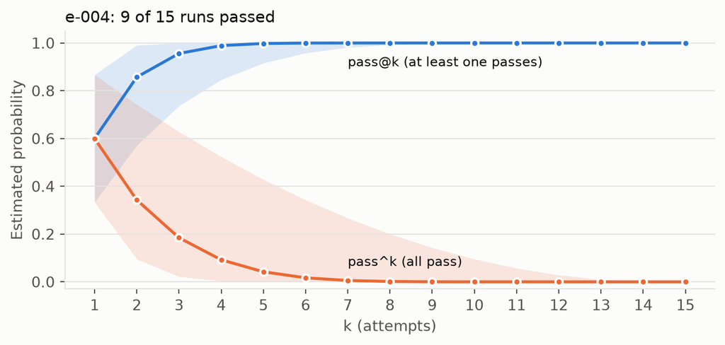

```python
case = PASSK_EXAMPLE
res = json.loads((ROOT / f"eval_results/{case}-15.json").read_text())
n, c = res["n"], res["successes"]
ks = list(range(1, n + 1))
at = [pass_at_k(n, c, k) for k in ks]
hat = [pass_hat_k(n, c, k) for k in ks]

display(Markdown(
    f"Example, **{case}** ({c}/{n} passed): pass@1 = {c / n:.2f}, "
    f"pass@3 = {pass_at_k(n, c, 3):.2f}, pass^3 = {pass_hat_k(n, c, 3):.2f}."
))

fig, ax = plt.subplots(figsize=(7, 3.4))
for ys, boot, color, label in [(at, pass_at_k_bootstrap, SERIES[0], "pass@k (at least one passes)"),
                               (hat, pass_hat_k_bootstrap, SERIES[1], "pass^k (all pass)")]:
    lo, hi = band(res["rewards"], ks, boot)
    ax.fill_between(ks, lo, hi, color=color, alpha=0.15, lw=0)
    ax.plot(ks, ys, color=color, lw=2, marker="o", ms=5, markeredgecolor=SURF, markeredgewidth=1.5)
    ax.annotate(label, (ks[6], ys[6]), xytext=(0, -16 if ys is at else 10), textcoords="offset points", color=INK, fontsize=9)
ax.set_xlabel("k (attempts)")
ax.set_ylabel("Estimated probability")
ax.set_ylim(-0.03, 1.05)
ax.set_xticks(ks)
ax.grid(axis="y", color=GRID, lw=0.8)
ax.set_title(f"{case}: {c} of {n} runs passed", loc="left", color=INK, fontsize=11)
plt.tight_layout()
plt.show()
```

Bands are 95% bootstrap intervals (2,000 resamples of the runs).

## 4. GitHub Actions runs

```python
display(Markdown(f"Pull request: <{CI['pull_request']}>. Agent model: `{CI['agent_model']}`. Case broken on purpose: **{CI['case_id']}**."))
rows = []
for label, run in [("1. Intentional regression", CI["regression_run"]), ("2. After the revert", CI["revert_run"])]:
    s = run["selected_case"]
    d = case_passes(s["kind"], s["observed_passes"], s["trials"])
    rows.append((label, f"`{run['commit']}`", run["change"], f"{s['observed_passes']}/{s['trials']}",
                 str(d["decision"]), run["result"], f"[run]({run['url']})"))
display(table(["Run", "Commit", "Change", f"{CI['case_id']} passes", f"{CI['case_id']} decision", "Job result", "Link"], rows))
other = CI["regression_run"].get("other_blocked_cases")
```

Pull request: https://github.com/jrnold/cartwheel-homeworks/pull/15. Agent model: `gpt-5.6-terra`. Case broken on purpose: **e-011**.

| Run | Commit | Change | e-011 passes | e-011 decision | Job result | Link |
| --- | --- | --- | --- | --- | --- | --- |
| 1. Intentional regression | `7d07c41` | Temporary system-prompt instruction: when a merchant asks about a policy, walk through the full policy background before answering. | 3/5 | block | blocked | [run](https://github.com/jrnold/cartwheel-homeworks/actions/runs/36802831747) |
| 2. After the revert | `1802b82` | git revert of 7d07c41 | 5/5 | pass | passed | [run](https://github.com/jrnold/cartwheel-homeworks/actions/runs/36803867922) |

Each run’s page has the per-case summary table and the Harbor job as a download.

## 5. Trial counts: 5, 10, and 15 observed runs

Each case ran 15 times. `n = 5` and `n = 10` use the first 5 and 10 runs. **e-004** is the required case; **e-008** and **e-009** use the judge.

| Runs observed | Metrics |
| --- | --- |
| `n = 5` | pass@1, pass@3, pass@5 |
| `n = 10` | pass@1, pass@3, pass@5 |
| `n = 15` | pass@1, pass@3, pass@5, pass@10, pass@15 |

```python
RESULTS = {cid: json.loads((ROOT / f"eval_results/{cid}-15.json").read_text()) for cid in TRIAL_COUNT_JOBS}
for cid, job in TRIAL_COUNT_JOBS.items():
    ts = trials(job, cid)
    assert [t["reward"] for t in ts] == RESULTS[cid]["rewards"], cid
    assert not any(t["error"] for t in ts), cid

rows = []
for cid, res in RESULTS.items():
    rows.append((cid, f"`{CASES[cid]['mode']}`", res["model"], f"{CASES[cid]['baseline_pass_rate']:.1f}",
                 f"{res['successes']}/{res['n']}"))
display(table(["Case", "Mode", "Agent model", "Baseline rate", "Passes"], rows))
```

| Case | Mode | Agent model | Baseline rate | Passes |
| --- | --- | --- | --- | --- |
| e-004 | `exposes_internal_identifiers` | gpt-5.6-terra | 0.8 | 9/15 |
| e-008 | `narrates_or_overexplains` | gpt-5.6-terra | 0.0 | 2/15 |
| e-009 | `narrates_or_overexplains` | gpt-5.6-terra | 0.0 | 1/15 |

```python
for cid, res in RESULTS.items():
    rows = []
    for comp in res["comparisons"]:
        pak = comp["pass_at_k"]
        lo, hi = comp["pass_at_k_uncertainty"]["1"]["bootstrap_ci95"]
        rows.append((comp["n"], comp["successes"], f"{pak['1']:.2f} [{lo:.2f}, {hi:.2f}]",
                     *(f"{pak[k]:.2f}" if k in pak else "–" for k in ("3", "5", "10", "15"))))
    display(Markdown(f"**{cid}**"))
    display(table(["n", "Passes", "pass@1 [95% CI]", "pass@3", "pass@5", "pass@10", "pass@15"], rows))
```

Table 3: pass@k by number of runs, with a 95% interval for pass@1.

**e-004**

| n | Passes | pass@1 [95% CI] | pass@3 | pass@5 | pass@10 | pass@15 |
| --- | --- | --- | --- | --- | --- | --- |
| 5 | 4 | 0.80 [0.40, 1.00] | 1.00 | 1.00 | – | – |
| 10 | 6 | 0.60 [0.30, 0.90] | 0.97 | 1.00 | – | – |
| 15 | 9 | 0.60 [0.33, 0.87] | 0.96 | 1.00 | 1.00 | 1.00 |

**e-008**

| n | Passes | pass@1 [95% CI] | pass@3 | pass@5 | pass@10 | pass@15 |
| --- | --- | --- | --- | --- | --- | --- |
| 5 | 1 | 0.20 [0.00, 0.60] | 0.60 | 1.00 | – | – |
| 10 | 1 | 0.10 [0.00, 0.30] | 0.30 | 0.50 | – | – |
| 15 | 2 | 0.13 [0.00, 0.33] | 0.37 | 0.57 | 0.90 | 1.00 |

**e-009**

| n | Passes | pass@1 [95% CI] | pass@3 | pass@5 | pass@10 | pass@15 |
| --- | --- | --- | --- | --- | --- | --- |
| 5 | 0 | 0.00 [0.00, 0.00] | 0.00 | 0.00 | – | – |
| 10 | 1 | 0.10 [0.00, 0.30] | 0.30 | 0.50 | – | – |
| 15 | 1 | 0.07 [0.00, 0.20] | 0.20 | 0.33 | 0.67 | 1.00 |

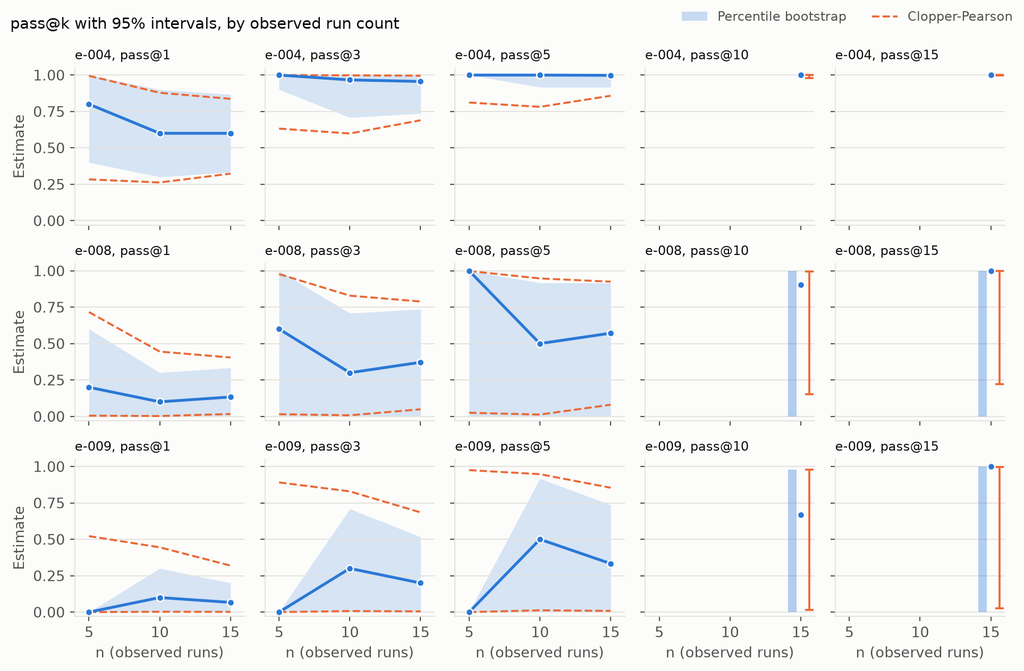

```python
NS = [5, 10, 15]
KS = ("1", "3", "5", "10", "15")
fig, axes = plt.subplots(len(RESULTS), len(KS), figsize=(10, 6.6), sharex=True, sharey=True)
for row, (cid, res) in zip(axes, RESULTS.items()):
    by_n = {comp["n"]: comp for comp in res["comparisons"]}
    for ax, k in zip(row, KS):
        ns = [n_ for n_ in NS if k in by_n[n_]["pass_at_k"]]  # pass@10 and pass@15 exist only at n = 15
        ys = [by_n[n_]["pass_at_k"][k] for n_ in ns]
        lo, hi = zip(*(by_n[n_]["pass_at_k_uncertainty"][k]["bootstrap_ci95"] for n_ in ns))
        cp_lo, cp_hi = zip(*(pass_at_k_clopper_pearson(n_, by_n[n_]["successes"], int(k)) for n_ in ns))
        if len(ns) > 1:
            ax.fill_between(ns, lo, hi, color=SERIES[0], alpha=0.18, lw=0)
            ax.plot(ns, cp_lo, color=SERIES[1], lw=1.4, ls="--")
            ax.plot(ns, cp_hi, color=SERIES[1], lw=1.4, ls="--")
        else:
            # One point: draw the two intervals side by side.
            ax.vlines([n_ - 0.6 for n_ in ns], lo, hi, color=SERIES[0], alpha=0.35, lw=6)
            # Drawn from its own ends: the estimate can lie above this interval.
            xs = [n_ + 0.6 for n_ in ns]
            ax.vlines(xs, cp_lo, cp_hi, color=SERIES[1], lw=1.4)
            for y in (cp_lo, cp_hi):
                ax.hlines(y, [x - 0.3 for x in xs], [x + 0.3 for x in xs], color=SERIES[1], lw=1.4)
        ax.plot(ns, ys, color=SERIES[0], lw=2, marker="o", ms=5, markeredgecolor=SURF, markeredgewidth=1)
        ax.set_title(f"{cid}, pass@{k}", loc="left", color=INK, fontsize=9)
        ax.grid(axis="y", color=GRID, lw=0.8)
        ax.set_xticks(NS)
        ax.set_xlim(4, 16)
    row[0].set_ylabel("Estimate")
for ax in axes[-1]:
    ax.set_xlabel("n (observed runs)")
axes[0][0].set_ylim(-0.03, 1.05)
fig.suptitle("pass@k with 95% intervals, by observed run count", x=0.01, ha="left", color=INK, fontsize=11)
fig.legend(handles=[plt.Rectangle((0, 0), 1, 1, color=SERIES[0], alpha=0.25, lw=0),
                    plt.Line2D([], [], color=SERIES[1], lw=1.4, ls="--")],
           labels=["Percentile bootstrap", "Clopper-Pearson"], loc="upper right", ncol=2,
           frameon=False, fontsize=9, labelcolor=INK2)
plt.tight_layout()
plt.show()
```

Shaded bands are 95% percentile bootstrap intervals (2,000 resamples of the runs). Dashed lines are 95% Clopper-Pearson intervals: an exact interval for the per-run pass rate p, mapped through pass@k = 1 − (1 − p)^k. Because that map is increasing, the pass@k interval keeps the guarantee of at least 95% coverage for every p. pass@10 and pass@15 need at least 10 and 15 runs, so they appear only at `n = 15`, with the bootstrap bar on the left and Clopper-Pearson on the right.

The two methods disagree most when a case rarely passes. A resample with no passes drives the bootstrap’s lower bound to 0, and when every run failed (e-009 at `n = 5`) the bootstrap has zero width. The bootstrap is also centred on the plug-in 1 − (1 − c/n)^k, which falls below the unbiased estimate as k grows. Clopper-Pearson has neither problem. At k close to n the unbiased estimate can fall above the Clopper-Pearson interval: with any pass at all, pass@15 from 15 runs is 1.